# Markowitz Portfolio

Doynikov A.

April 27, 2021

# Портфель ценных бумаг. Диверсификация Марковитца.

Методология инвестирования в ценные бумаги десятилетиями разрабатывалась американскими биржевыми брокерами. Некоторые из них не ленились осмыслить личный опыт и опыт коллег. Определяющую роль в становлении современной теории инвестирования сыграли работы американского финансиста Гарри Марковитца написанные в начале 50-х годов и заложившие основы теории инвестиционного портфеля. Спустя сорок с лишним лет – в 1990 году Гарри Марковитц получил Нобелевскую премию по экономике.

Пусть $S_{t}^{i}$ стоимость в момент времени $t$ акции с номером $i=1,...,N$ и пусть некий инвестор приобрел $b_{i}≥0; \mspace{25mu} i=1,...,N$ каждой из акций. Тогда вектор

$$b=b_1,...,b_{N}$$

будем называть портфелем ценных бумаг или просто портфелем.

Через $\Pi_{t}(b)$, где

$$\Pi_{t}(b)=\sum_{i=1}^{N}S_{t}^{i}b_{i}$$
будем обозначать стоимость портфеля в момент времени $t$.

Основные идеи Марковитца рассмотрим на примере одношаговой задачи инвестирования. Т.е. будем интересоватья значением стоимости портфеля в два произвольно выбранных момента времени, которые для краткости будем считать равными 0 и 1.

Предположим, что в момент времени $t=0$ акция с номером $i$ стоила $S_0^{i}$, а в момент $t=1$ - ее цена будет $S_1^{i}$. Для дальнейших выкладок удобно следующее представление

$$S_1^{i}=(1+r_{i})S_0^{i},\mspace{25mu}i=1,...,N$$
где $r_{i}$- назовем процентной ставкой по акции с номером $i$ за рассматриваемый промежуток времени. Тогда стоимость портфеля в момент времени 1. можно записать следующим образом

$$\Pi_1=\sum_{i=1}^{N}(1+r_{i})S_0^{i}b_{i}$$

Естественно желание чтобы $\Pi_1$ было как можно “побольше”, но с учетов “риска” который возникает при желании иметь это “побольше”.

Будем считать, что все $r_{i}$- некоторые случайные величины с конечными математическими ожиданиями и вторыми моментами.

Г.Марковитц предложил следующие характеристики портфеля $E[\Pi_1]$ - математическое ожидание $\Pi_1$ и .$D[\Pi_1]$-дисперсию $\Pi_1$.

В зависимости от критерия оптимальности можно по-разному сформулировать и оптимизационную задачу выбора наилучшего портфеля. В частности, естественна следующая вариационная задача. Найти

$$\sup E[\Pi_1(b)]$$

в предположении, что $\sup$ берется по всем тем портфелям $b$, для которых выполнены следующие ограничения

$\Pi_0(b)$ фиксировано и равно $\Pi_0$

```
и
```

$D[\Pi_1(b)] ≤ \sigma$

Множестово портфелей, удовлетворяющих первому из этих требований будем обозначать через $B(П_0)$.

Марковитц показал, что геометрическое место точек $(E[\Pi_1(b)],√(D[П_1(b)]))$ предствляет собой выпуклое множество и интересующие нас портфели при каждом заданном $\sigma$ находятся на верхней ее границе. Он назвал эти портфели эффективными.

В одношаговой задаче оптимизации можно обойтись без значений величин $S_1^1,...,S_1^{N}$ а оперировать в терминах процентных ставок.

Действительно. Пусть $b∈B(\Pi_0).$ Введем величины $d=(d_1,...,d_{N})$полаагая

$$d_{i}=((b_{i}S_0^{i})/(\Pi_0))$$
Тогда очевидно, что все $d_{i}≥0$ и $\sum_{i=1}^{N}d_{i}=1$.

Представим $\Pi_1(b)$ в виде

$$\Pi_1(b)=(1+R(b))\Pi_0(b)$$
где

$$R(b)=\sum_{i=1}^{N}r_{i}b_{i}$$

Пусть

$$r(d)=\sum_{i=1}^{N}r_{i}d_{i}$$
Ясно, что

$$R(b)=((\Pi_1(b))/(\Pi_0(b)))-1=((\Pi_1(b))/(\Pi_0))-1=((\sum_{i=1}^{N}S_1^{i}b_{i})/(\Pi_0))-1=$$
$$\sum_{i=1}^{N}d_{i}((S_1^{i})/(S_0^{i}))-1=\sum_{i=1}^{N}d_{i}(((S_1^{i})/(S_0^{i}))-1)=\sum_{i=1}^{N}d_{i}r_{i}=r(d)$$

Итак

$$R(b)=r(d)$$
Откуда следует, что для всех $b∈B(\Pi_0)$

$$\Pi_1(b)=\Pi_0(1+r(d))$$
и, следовательно, с точки зрения оптимизационных задач для $\Pi_1(b)$ можно оперировать $r(d)$.

Теперь посмотрим, чего можно добиться диверсификацией портфеля. Для начала вспомним, что для двух случайных величин $\xi_1$ и $\xi_2$ с конечными дисперсиями $\sigma_1^2$ и $\sigma_2^2$ соответсвенно, а также для проивольных констант $c_1$ и $с_2$
$$D[c_1\xi_1+c_2\xi_2]=(c_1\sigma_1-c_2\sigma_2)^2+2c_1c_2\sigma_1\sigma_2(1+\sigma_{1,2})$$
где
$$\sigma_{1,2}=((cov(\xi_1,\xi_2))/(\sigma_1\sigma_2))$$
Отсюда следует, что если $c_1\sigma_1=c_2\sigma_2$, а $\sigma_{1,2}=-1$, то
$$D[c_1\xi_1+c_2\xi_2]=0$$
Это означает, что если корреляция случайных величин $\xi_1$ и $\xi_2$ равна $-1$, то подбирая константы $c_1$ и $с_2$ можно добиться нулевой дисперсии. Правда при этом среднее значение $E[c_1\xi_1+c_2\xi_2]$ может тоже маленьким получиться.

Изложенный эффект называется эффектом Марковитца. Он является одной из основных идей диверсификации.

*При составлении портфеля необходимо стремиться к тому, чтобы инвестиции по возможности делать в отрицательно коррелируемые бумаги.*

Теперь рассмотрим другой вывод из диверсификациии. Пусть $\xi_1,...,\xi_{N}$ последовательность некоррелированных случаных величин с конечными дисперсиями $\sigma_{i}^2<C,\mspace{25mu} i=1,...,N$. Тогда

$$D[\sum_{i=1}^{N}d_{i}\xi_{i}]=\sum_{i=1}^{N}d_{i}^2D\xi_{i}≤max(\sigma_1^2,...,\sigma_{N}^2)\sum_{i=1}^{N}d_{i}^2≤C\sum_{i=1}^{N}d_{i}^2$$

Берем $d_{i}=1/N,\mspace{25mu} i=1,...,N$. Тогда

$$D[\sum_{i=1}^{N}d_{i}\xi_{i}]≤(C/N)->0$$
при $N→∞$

Этот эффект называется эффектом некоррелированности Марковитца и формулируется следующим образом.

*Если инвестиции производятся в некоррелированные ценные бумаги, то для уменьшения риска надо, по возможности, брать как можно большее их число*.

Вернемся к вопросу о дисперсии $r(d)$

$$Dr(d)=\sum_{i=1}^{N}d_{i}^2Dr_{i}+\sum_{i,j=1,i≠j}^{N}d_{i}d_{j}cov(r_{i}r_{j})$$

Опять возьмем $d_{i}=1/N \mspace{25mu} i=1,...,N.$ Тогда
$$\sum_{i=1}^{N}d_{i}^2Dr_{i}=((1/N))^2N(1/N)\sum_{i=1}^{N}Dr_{i}=(1/N)\sigma_{}^2$$

```r
library(fPortfolio)
library(quadprog)
library(xts)
```

# Построение оптимального по Марковитцу портфеля

Пусть $r_i$ доходность $i$-го актива $i=1,...,N$. $\mu_{i} = E r_{i}$- математическое ожидание доходности и $\sigma^2_{i} = E (r_{i}-\mu_{i})^2$- дисперсия доходности. Пусть $d_i\ge0$ - доля $i$-го актива в портфеле, $\sum_{i=1}^Nd_i=1$. Тогда ранее мы показали, что математическое ожидание доходности всего портфеля
$$\mu= E R = E[\sum_{i=1}^N d_i r_i]=\sum_{i=1}^N d_i\mu_i$$
Дисперсия доходности портфеля
$$\sigma^2(R)=E(\sum_{i=1}^N d_i(r_i-\mu_i)^2)=E[\sum_{i=1}^N \sum_{j=1}^N d_id_j(r_i-\mu_i)(r_j-\mu_j)] =\sum_{i=1}^N \sum_{j=1}^N d_id_jE[(r_i-\mu_i)(r_j-\mu_j)]=$$
$$=\sum_{i=1}^N \sum_{j=1}^N d_id_j covar(r_i,r_j)= \sum_{i=1}^N \sum_{j=1}^Nd_id_j\sigma_{i,j}=d'\Sigma d$$
где $\Sigma=[\sigma_{i,j};i,j=1,...,N]$- ковариационная матрица доходностей.

Мы решаем задачу нахождения такого вектора $d=(d_1,...,d_N)$
$$\min_{d}d'\Sigma d$$
при ограничениях
$$\sum_{i=1}^Nd_i=1$$
и
$$\sum_{i=1}^N d_i\mu_i=\mu_p$$
где $\mu_p$ - заданная доходность портфеля.

## Коэффициент Шарпа

Коэффициент Шарпа был разработан нобелевским лауреатом Вильямом Шарпом в 1966 году и используется для измерения уровня риска в инвестиционном портфеле . Следовательно, чем выше коэффициент Шарпа, тем лучше результаты, которые показывает инвестиционный портфель по отношению к принятым рискам.

Коэффициент Шарпа для портфеля вычисляется по формуле
$$S=((E[r_{p}-r])/(√(D[r_{p}-r])))$$

где

$r_{p}$-доходность портфеля за некоторый промежуток времени;

$r$ - безрисковая доходность за такой же период времени

$E[],D[]$- математическое ожидание и дисперсия. При сравнении двух портфелей с одинаковой доходностью предпочтительнее является портфель с большим коэффициентом Шарпа, а следовательно с меньшем риском $D[r_{p}-r]$

## Пример построения оптимального портфеля на R

Считываем данные

```r
Path <-'./'
histData <- read.table(paste0(Path,'HistoricData.csv'),sep = ',', header = TRUE )
head(histData)
```

```
##   ï...DATE. GAZPROM     VTB  GMK   LKOH MAGNIT PZOL ROSTEL RUSGIDRO   SBER
## 1    4/5/17  130.69 0.06690 9186 3057.0   9470 4425  78.20   0.9699 168.10
## 2    4/6/17  130.50 0.06615 9133 3057.5   9550 4409  77.78   0.9720 167.49
## 3    4/7/17  128.72 0.06559 9025 2991.0   9430 4409  77.22   0.9416 161.49
## 4   4/10/17  126.16 0.06473 8956 2956.0   9360 4396  76.33   0.8800 155.20
## 5   4/11/17  126.00 0.06490 8964 2968.0   9265 4404  75.90   0.8780 156.00
## 6   4/12/17  125.05 0.06410 8924 2949.5   9100 4402  75.88   0.8540 150.28
##     SNGZ ROSNEFT TATNEFT   MICEX
## 1 29.700  338.20  369.85 2056.32
## 2 30.000  337.95  369.45 2054.69
## 3 29.660  335.95  357.70 2020.23
## 4 28.500  327.20  343.30 1971.23
## 5 28.235  330.50  342.15 1977.95
## 6 27.320  325.10  334.95 1947.88
```

```r
(nAsset <- dim(histData)[2])
```

```
## [1] 14
```

```r
(nDays <- dim(histData)[1])
```

```
## [1] 498
```

Переводим первый столбец в переменную Dates типа `Date`

```r
Dates <- histData[,1]
Dates <- as.Date(Dates, "%m/%d/%y")
```

Убираем первый столбец остальные переводим в тип `xts`( time series).

```r
histData <- histData[2:nAsset]
sample.xts <- as.xts(histData, order.by = Dates)
head(sample.xts)
```

```
##            GAZPROM     VTB  GMK   LKOH MAGNIT PZOL ROSTEL RUSGIDRO   SBER
## 2017-04-05  130.69 0.06690 9186 3057.0   9470 4425  78.20   0.9699 168.10
## 2017-04-06  130.50 0.06615 9133 3057.5   9550 4409  77.78   0.9720 167.49
## 2017-04-07  128.72 0.06559 9025 2991.0   9430 4409  77.22   0.9416 161.49
## 2017-04-10  126.16 0.06473 8956 2956.0   9360 4396  76.33   0.8800 155.20
## 2017-04-11  126.00 0.06490 8964 2968.0   9265 4404  75.90   0.8780 156.00
## 2017-04-12  125.05 0.06410 8924 2949.5   9100 4402  75.88   0.8540 150.28
##              SNGZ ROSNEFT TATNEFT   MICEX
## 2017-04-05 29.700  338.20  369.85 2056.32
## 2017-04-06 30.000  337.95  369.45 2054.69
## 2017-04-07 29.660  335.95  357.70 2020.23
## 2017-04-10 28.500  327.20  343.30 1971.23
## 2017-04-11 28.235  330.50  342.15 1977.95
## 2017-04-12 27.320  325.10  334.95 1947.88
```

Нормируем данные

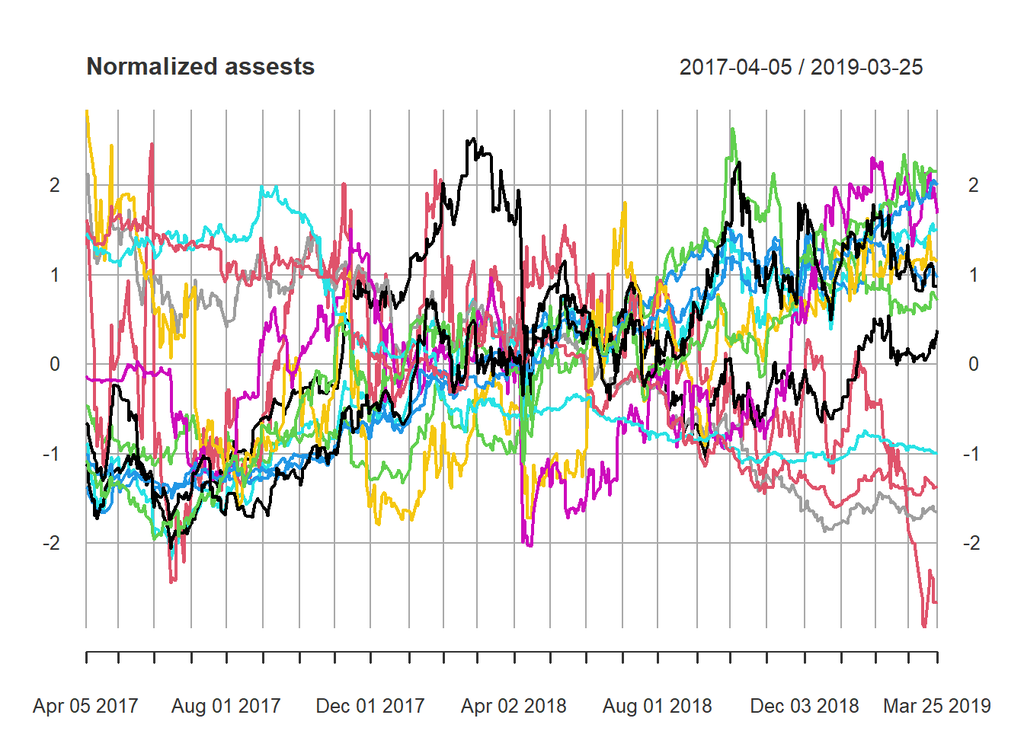

```r
std_data <- scale(sample.xts)
plot(std_data,lty=1,main='Normalized assests',type = "l")
```

Переходим к рядам из геометрических доходностей
$$r_{t,i}=\frac{S_{t,i}}{S_{t-1,i}-1};t=1,..,T; i=1,...N$$

```r
stock.returns <- returns(sample.xts,method = 'discrete')
head(stock.returns)
```

[output not shown]

Убираем первую строку

```r
stock.returns<-stock.returns[2:nDays,]
head(stock.returns)
```

```
##                 GAZPROM          VTB           GMK         LKOH       MAGNIT
## 2017-04-06 -0.001453822 -0.011210762 -0.0057696495  0.000163559  0.008447730
## 2017-04-07 -0.013639847 -0.008465608 -0.0118252491 -0.021749796 -0.012565445
## 2017-04-10 -0.019888129 -0.013111755 -0.0076454294 -0.011701772 -0.007423118
## 2017-04-11 -0.001268231  0.002626294  0.0008932559  0.004059540 -0.010149573
## 2017-04-12 -0.007539683 -0.012326656 -0.0044622936 -0.006233154 -0.017808958
## 2017-04-13 -0.004078369 -0.001560062 -0.0166965486 -0.013392100  0.006593407
##                     PZOL        ROSTEL     RUSGIDRO         SBER         SNGZ
## 2017-04-06 -0.0036158192 -0.0053708440  0.002165172 -0.003628792  0.010101010
## 2017-04-07  0.0000000000 -0.0071997943 -0.031275720 -0.035823034 -0.011333333
## 2017-04-10 -0.0029485144 -0.0115255115 -0.065420561 -0.038949780 -0.039109912
## 2017-04-11  0.0018198362 -0.0056334338 -0.002272727  0.005154639 -0.009298246
## 2017-04-12 -0.0004541326 -0.0002635046 -0.027334852 -0.036666667 -0.032406588
## 2017-04-13 -0.0004543389 -0.0217448603  0.015925059  0.011445302  0.001647145
##                  ROSNEFT     TATNEFT         MICEX
## 2017-04-06 -0.0007392076 -0.00108152 -0.0007926782
## 2017-04-07 -0.0059180352 -0.03180403 -0.0167713864
## 2017-04-10 -0.0260455425 -0.04025720 -0.0242546641
## 2017-04-11  0.0100855746 -0.00334984  0.0034090390
## 2017-04-12 -0.0163388805 -0.02104340 -0.0152026088
## 2017-04-13 -0.0098431252 -0.01477833 -0.0016325441
```

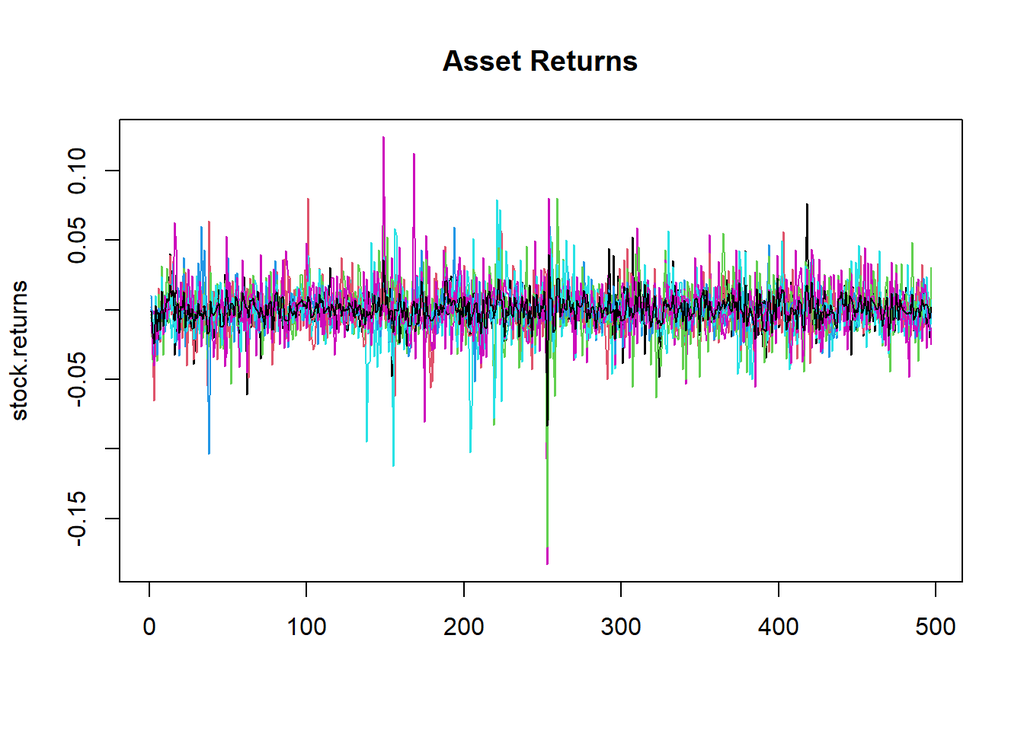

```r
matplot(stock.returns,lty=1,main='Asset Returns',type = "l")
```

Считаем ковариационную матрицу доходностей

```r
(cov <- cov(stock.returns))
```

```
##               GAZPROM          VTB          GMK         LKOH       MAGNIT
## GAZPROM  1.804168e-04 8.183721e-05 7.862566e-05 9.304106e-05 2.845610e-05
## VTB      8.183721e-05 2.382930e-04 8.174296e-05 7.463674e-05 6.776495e-05
## GMK      7.862566e-05 8.174296e-05 2.838349e-04 9.043222e-05 5.319840e-05
## LKOH     9.304106e-05 7.463674e-05 9.043222e-05 1.977057e-04 3.731398e-05
## MAGNIT   2.845610e-05 6.776495e-05 5.319840e-05 3.731398e-05 3.761824e-04
## PZOL     4.350449e-05 5.200294e-05 9.769942e-05 4.653355e-05 3.419297e-05
## ROSTEL   3.339477e-05 3.524960e-05 4.587289e-05 2.303692e-05 3.389150e-05
## RUSGIDRO 5.997791e-05 7.112399e-05 5.899687e-05 5.753030e-05 4.615084e-05
## SBER     1.148326e-04 1.306122e-04 1.276368e-04 1.019470e-04 5.592859e-05
## SNGZ     7.730307e-05 6.520775e-05 6.591702e-05 7.977625e-05 3.701748e-05
## ROSNEFT  8.959217e-05 6.977783e-05 8.351393e-05 1.110482e-04 3.605875e-05
## TATNEFT  1.024404e-04 6.563878e-05 8.166438e-05 1.332248e-04 2.264113e-05
## MICEX    9.260455e-05 8.153246e-05 9.512852e-05 9.666649e-05 5.142130e-05
##                  PZOL       ROSTEL     RUSGIDRO         SBER         SNGZ
## GAZPROM  4.350449e-05 3.339477e-05 5.997791e-05 1.148326e-04 7.730307e-05
## VTB      5.200294e-05 3.524960e-05 7.112399e-05 1.306122e-04 6.520775e-05
## GMK      9.769942e-05 4.587289e-05 5.899687e-05 1.276368e-04 6.591702e-05
## LKOH     4.653355e-05 2.303692e-05 5.753030e-05 1.019470e-04 7.977625e-05
## MAGNIT   3.419297e-05 3.389150e-05 4.615084e-05 5.592859e-05 3.701748e-05
## PZOL     3.274098e-04 2.693373e-05 4.595477e-05 1.125945e-04 4.371571e-05
## ROSTEL   2.693373e-05 1.051595e-04 2.919536e-05 3.760985e-05 3.039464e-05
## RUSGIDRO 4.595477e-05 2.919536e-05 2.269115e-04 9.569839e-05 5.403525e-05
## SBER     1.125945e-04 3.760985e-05 9.569839e-05 3.737501e-04 7.870882e-05
## SNGZ     4.371571e-05 3.039464e-05 5.403525e-05 7.870882e-05 1.824748e-04
## ROSNEFT  3.900591e-05 1.912259e-05 5.026988e-05 1.046837e-04 6.678110e-05
## TATNEFT  3.054580e-05 2.234594e-05 5.151025e-05 9.778546e-05 9.107933e-05
## MICEX    6.050924e-05 2.859593e-05 6.072957e-05 1.383423e-04 7.010906e-05
##               ROSNEFT      TATNEFT        MICEX
## GAZPROM  8.959217e-05 1.024404e-04 9.260455e-05
## VTB      6.977783e-05 6.563878e-05 8.153246e-05
## GMK      8.351393e-05 8.166438e-05 9.512852e-05
## LKOH     1.110482e-04 1.332248e-04 9.666649e-05
## MAGNIT   3.605875e-05 2.264113e-05 5.142130e-05
## PZOL     3.900591e-05 3.054580e-05 6.050924e-05
## ROSTEL   1.912259e-05 2.234594e-05 2.859593e-05
## RUSGIDRO 5.026988e-05 5.151025e-05 6.072957e-05
## SBER     1.046837e-04 9.778546e-05 1.383423e-04
## SNGZ     6.678110e-05 9.107933e-05 7.010906e-05
## ROSNEFT  2.057420e-04 1.099168e-04 8.467613e-05
## TATNEFT  1.099168e-04 3.194425e-04 9.466526e-05
## MICEX    8.467613e-05 9.466526e-05 8.735595e-05
```

Зададим матрицу `Amat` и вектор `bvec` ограничений. Вектор столбец решений $d$ должен удовлетворять ограничениям вида $d^T Amat[,k] \ge bvec[k];k=1,...,meq+mge$

где:

$Amat[,k]$ - $k$-й вектор столбец матрицы `Amat`;

$bvec[k]$ - $k$-й элемент вектора `bvec`;

$meq$ - количество ограничений в виде точного равенства;

$mge$ - количество ограничений в виде неравенства $\ge$.

Более точное описание устройства матрицы `Amat` дадим позднее.

```r
  n <- ncol(cov)
  Amat <- matrix (1, nrow=n)
  Amat <- cbind(Amat, -diag(n))
  bvec <- 1
  meq <- 1
```

```r
max.allocation <- 0.45
bvec <- c(bvec, rep(-max.allocation, n))
bvec
```

```
##  [1]  1.00 -0.45 -0.45 -0.45 -0.45 -0.45 -0.45 -0.45 -0.45 -0.45 -0.45 -0.45
## [13] -0.45 -0.45
```

Зададим максимальную доходность и шаг изменения доходности и определим количество итераций цикла по доходности.

```r
  risk.premium.up <-0.5
  risk.increment <- 0.01
  (loops <- risk.premium.up / risk.increment + 1)
```

```
## [1] 51
```

```r
  loop <- 1
```

Инициализируем матрицу, где будем хранить оптимальные портфели и различные статистики

```r
  eff <- matrix(nrow=loops, ncol=n+3)
  colnames(eff) <- c(colnames(stock.returns), "Std.Dev", "Exp.Return", "sharpe")
```

Получаем оптимальный портфель, доходность, стандартное отклонение и коэффициент Шарпа на каждой итерации

```r
mu <- colMeans(stock.returns)

for (i in seq(from=0, to=risk.premium.up, by=risk.increment)){
    dvec <- mu * i
    sol <- solve.QP(cov, dvec=dvec, Amat=Amat, bvec=bvec, meq=meq)
    eff[loop,"Std.Dev"] <- sqrt(sum(sol$solution *colSums((cov * sol$solution))))
    eff[loop,"Exp.Return"] <- as.numeric(sol$solution %*% colMeans(stock.returns))
    eff[loop,"sharpe"] <- eff[loop,"Exp.Return"] / eff[loop,"Std.Dev"]
    eff[loop,1:n] <- sol$solution
    loop <- loop+1
}
eff <- as.data.frame(eff)
head(eff)
```

```
##        GAZPROM         VTB         GMK        LKOH       MAGNIT       PZOL
## 1 -0.013811151  0.02376924 -0.04778191 -0.02244931  0.044962547 0.07962074
## 2 -0.006129517 -0.04332861 -0.01258108  0.06674479  0.006394563 0.09307368
## 3  0.001552117 -0.11042646  0.02261975  0.15593890 -0.032173421 0.10652661
## 4  0.009233752 -0.17752430  0.05782058  0.24513300 -0.070741405 0.11997955
## 5  0.016915386 -0.24462215  0.09302140  0.33432711 -0.109309390 0.13343249
## 6  0.026210347 -0.31079454  0.12931743  0.42363878 -0.146746102 0.14783127
##      ROSTEL    RUSGIDRO         SBER        SNGZ      ROSNEFT     TATNEFT MICEX
## 1 0.3823554  0.08468301 -0.126288449  0.06348397 0.0764734804 0.004982481  0.45
## 2 0.3976457  0.02239178 -0.100010853  0.02028778 0.0612825258 0.044229220  0.45
## 3 0.4129361 -0.03989945 -0.073733257 -0.02290841 0.0460915711 0.083475960  0.45
## 4 0.4282264 -0.10219068 -0.047455661 -0.06610459 0.0309006165 0.122722699  0.45
## 5 0.4435168 -0.16448191 -0.021178065 -0.10930078 0.0157096618 0.161969439  0.45
## 6 0.4500000 -0.22545127  0.004682864 -0.15093835 0.0008990401 0.201350530  0.45
##       Std.Dev    Exp.Return      sharpe
## 1 0.007298986 -0.0001493587 -0.02046294
## 2 0.007612124  0.0003175640  0.04171819
## 3 0.008482459  0.0007844868  0.09248342
## 4 0.009762082  0.0012514096  0.12819085
## 5 0.011312950  0.0017183323  0.15189074
## 6 0.013032633  0.0021835958  0.16754833
```

Определяем точку на , где коэффициент Шарпа максимален

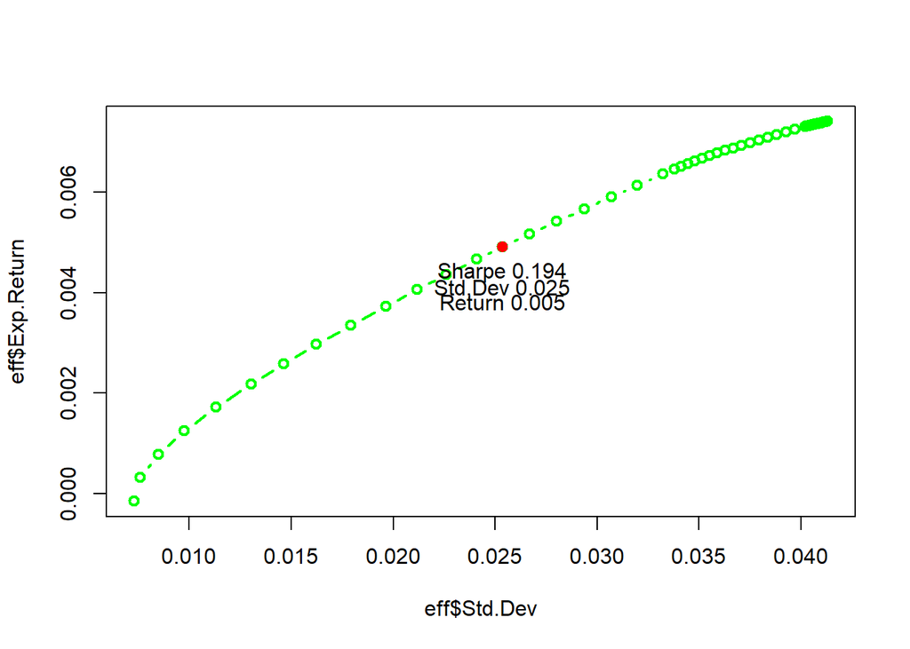

```r
eff.optimal.point <- eff[eff$sharpe==max(eff$sharpe),]

plot(eff$Std.Dev,eff$Exp.Return,type = 'b',pch =21,col = 'green',lwd = 2)
points(eff.optimal.point$Std.Dev,eff.optimal.point$Exp.Return,pch = 20,col = 'red',lwd = 4)
text(eff.optimal.point$Std.Dev,eff.optimal.point$Exp.Return-0.0005,paste('Sharpe',round(eff.optimal.point$sharpe,3)))
text(eff.optimal.point$Std.Dev,eff.optimal.point$Exp.Return-0.0008,paste('Std.Dev',round(eff.optimal.point$Std.Dev,3)))
text(eff.optimal.point$Std.Dev,eff.optimal.point$Exp.Return-0.0011,paste('Return',round(eff.optimal.point$Exp.Return,3)))
```

```r
eff.optimal.point
```

```
##      GAZPROM        VTB  GMK LKOH     MAGNIT      PZOL ROSTEL   RUSGIDRO
## 14 0.2793145 -0.7909088 0.45 0.45 -0.4236062 0.2903342   0.45 -0.6608415
##         SBER       SNGZ   ROSNEFT TATNEFT MICEX    Std.Dev  Exp.Return
## 14 0.2317485 -0.3266258 0.1505851    0.45  0.45 0.02537488 0.004916999
##       sharpe
## 14 0.1937743
```

Проверим выполнение ограничений. Это пояснит устройство матрицы `Amat` и вектора `bvec`, которые имеет размер

```r
dim(Amat)
```

```
## [1] 13 14
```

```r
length(bvec)
```

```
## [1] 14
```

и устроены `Amat` и `bvec` так

```r
   Amat
```

```
##       [,1] [,2] [,3] [,4] [,5] [,6] [,7] [,8] [,9] [,10] [,11] [,12] [,13]
##  [1,]    1   -1    0    0    0    0    0    0    0     0     0     0     0
##  [2,]    1    0   -1    0    0    0    0    0    0     0     0     0     0
##  [3,]    1    0    0   -1    0    0    0    0    0     0     0     0     0
##  [4,]    1    0    0    0   -1    0    0    0    0     0     0     0     0
##  [5,]    1    0    0    0    0   -1    0    0    0     0     0     0     0
##  [6,]    1    0    0    0    0    0   -1    0    0     0     0     0     0
##  [7,]    1    0    0    0    0    0    0   -1    0     0     0     0     0
##  [8,]    1    0    0    0    0    0    0    0   -1     0     0     0     0
##  [9,]    1    0    0    0    0    0    0    0    0    -1     0     0     0
## [10,]    1    0    0    0    0    0    0    0    0     0    -1     0     0
## [11,]    1    0    0    0    0    0    0    0    0     0     0    -1     0
## [12,]    1    0    0    0    0    0    0    0    0     0     0     0    -1
## [13,]    1    0    0    0    0    0    0    0    0     0     0     0     0
##       [,14]
##  [1,]     0
##  [2,]     0
##  [3,]     0
##  [4,]     0
##  [5,]     0
##  [6,]     0
##  [7,]     0
##  [8,]     0
##  [9,]     0
## [10,]     0
## [11,]     0
## [12,]     0
## [13,]    -1
```

```r
   bvec
```

```
##  [1]  1.00 -0.45 -0.45 -0.45 -0.45 -0.45 -0.45 -0.45 -0.45 -0.45 -0.45 -0.45
## [13] -0.45 -0.45
```

- Проверим, что $\sum_{i=1}^N d_i=1$ или в учетом построения матрица `Amat` следует проверить,что $d^TAmat[,1]= 1$.

```r
      d_tr <- as.matrix(eff.optimal.point[1:n],nrow = 1)
      d_tr
```

```
##      GAZPROM        VTB  GMK LKOH     MAGNIT      PZOL ROSTEL   RUSGIDRO
## 14 0.2793145 -0.7909088 0.45 0.45 -0.4236062 0.2903342   0.45 -0.6608415
##         SBER       SNGZ   ROSNEFT TATNEFT MICEX
## 14 0.2317485 -0.3266258 0.1505851    0.45  0.45
```

```r
      d_tr%*%Amat[,1]
```

```
##    [,1]
## 14    1
```

```r
      (d_tr%*%Amat[,2])
```

```
##          [,1]
## 14 -0.2793145
```

```r
      (d_tr%*%Amat[,3])
```

```
##         [,1]
## 14 0.7909088
```

```r
      (d_tr%*%Amat[,4])
```

```
##     [,1]
## 14 -0.45
```

```r
      (d_tr%*%Amat[,n+1])
```

```
##     [,1]
## 14 -0.45
```

В пакете *library(fPortfolio)* cодержится много различных функций как построения эффективных портфелей, так и визуализации результатов. Далее посмотрим только некоторые из них.

Строим эффективные портфели по Марковитцу

```r
stock.returns<- as.timeSeries(stock.returns)

Frontier = portfolioFrontier(stock.returns, constraints = "LongOnly")
summary(Frontier)
```

```
##
## Title:
##  MV Portfolio Frontier
##  Estimator:         covEstimator
##  Solver:            solveRquadprog
##  Optimize:          minRisk
##  Constraints:       LongOnly
##  Portfolio Points:  5 of 49
##
## Portfolio Weights:
##    GAZPROM    VTB    GMK   LKOH MAGNIT   PZOL ROSTEL RUSGIDRO   SBER   SNGZ
## 1   0.0000 0.0000 0.0000 0.0000 0.8614 0.0000 0.0000   0.1386 0.0000 0.0000
## 13  0.0000 0.1597 0.0000 0.0000 0.1769 0.0000 0.3090   0.2362 0.0000 0.1183
## 25  0.0000 0.0000 0.0000 0.0000 0.0499 0.0584 0.3869   0.0707 0.0000 0.0668
## 37  0.0000 0.0000 0.0788 0.2946 0.0000 0.1091 0.3205   0.0000 0.0000 0.0000
## 49  0.0000 0.0000 0.0000 0.0000 0.0000 0.0000 0.0000   0.0000 0.0000 0.0000
##    ROSNEFT TATNEFT  MICEX
## 1   0.0000  0.0000 0.0000
## 13  0.0000  0.0000 0.0000
## 25  0.0608  0.0068 0.2997
## 37  0.0058  0.1554 0.0358
## 49  0.0000  1.0000 0.0000
##
## Covariance Risk Budgets:
##    GAZPROM    VTB    GMK   LKOH MAGNIT   PZOL ROSTEL RUSGIDRO   SBER   SNGZ
## 1   0.0000 0.0000 0.0000 0.0000 0.9665 0.0000 0.0000   0.0335 0.0000 0.0000
## 13  0.0000 0.1776 0.0000 0.0000 0.2373 0.0000 0.2195   0.2721 0.0000 0.0934
## 25  0.0000 0.0000 0.0000 0.0000 0.0494 0.0586 0.3867   0.0702 0.0000 0.0667
## 37  0.0000 0.0000 0.0875 0.3693 0.0000 0.0971 0.2021   0.0000 0.0000 0.0000
## 49  0.0000 0.0000 0.0000 0.0000 0.0000 0.0000 0.0000   0.0000 0.0000 0.0000
##    ROSNEFT TATNEFT  MICEX
## 1   0.0000  0.0000 0.0000
## 13  0.0000  0.0000 0.0000
## 25  0.0610  0.0069 0.3005
## 37  0.0050  0.2084 0.0307
## 49  0.0000  1.0000 0.0000
##
## Target Returns and Risks:
##       mean     Cov    CVaR     VaR
## 1  -0.0016  0.0172  0.0447  0.0271
## 13 -0.0008  0.0088  0.0219  0.0146
## 25  0.0000  0.0076  0.0181  0.0117
## 37  0.0008  0.0091  0.0178  0.0126
## 49  0.0016  0.0179  0.0320  0.0240
##
## Description:
##  Fri Apr 30 11:52:48 2021 by user: Doynikov Alexandr
```

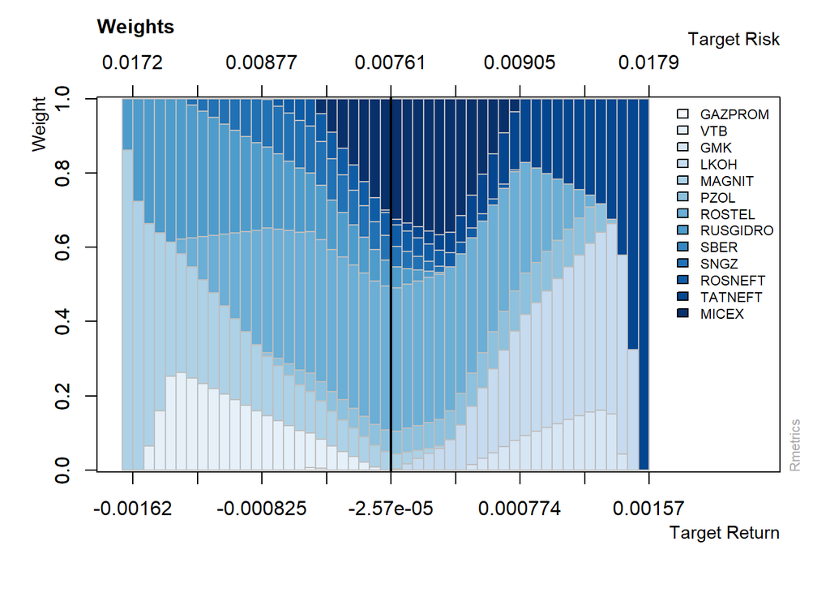

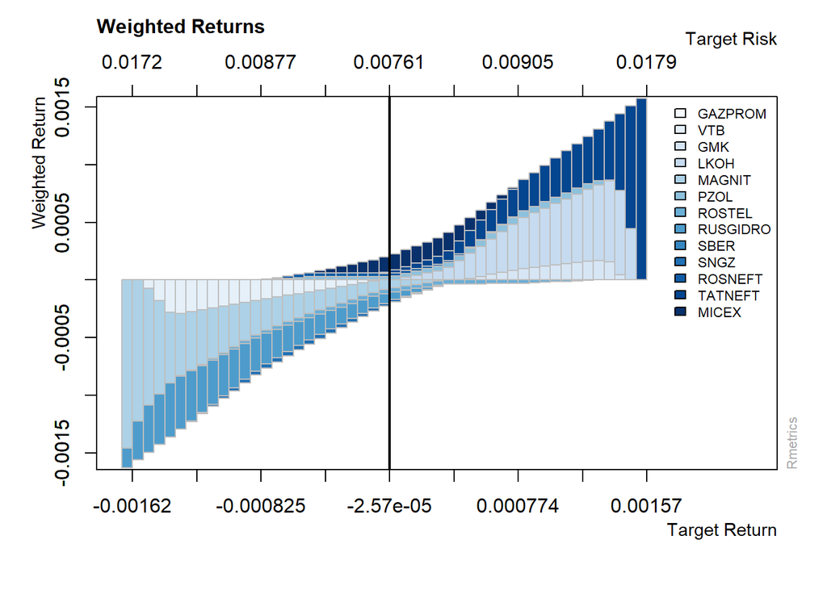

[figure not shown]

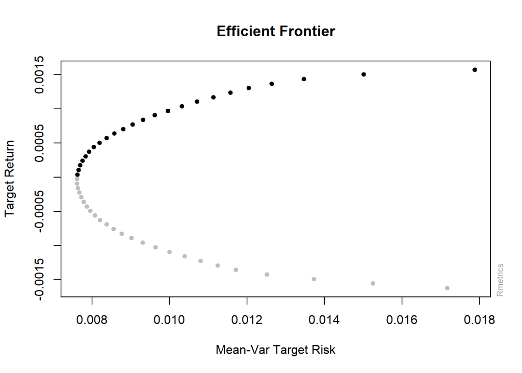

Рисуем эффективные портфели Добавляем к рисунку результаты портфелей:

[figure not shown]

```r
frontierPlot(Frontier, pch = 19, xlim = c(0.005, 0.03), ylim = c(-0.002, 0.005))
grid()
abline(h = 0, col = "grey")
abline(v = 0, col = "grey")
monteCarloPoints(Frontier, mcSteps = 5000, return = "mean",
                 risk = "Cov", auto = TRUE,col = 'green',pch = 20)
minvariancePoints(Frontier, pch = 19, col = "red")
equalWeightsPoints(Frontier, pch = 15, col = "grey")
singleAssetPoints(Frontier, pch = 19, cex = 1.5, col = topo.colors(6))
sharpeRatioLines(Frontier, col = "orange", lwd = 2)
```